# Lecture 9: Pipes

Joong-Ho Won @ SNU

August 30, 2018

# Programming

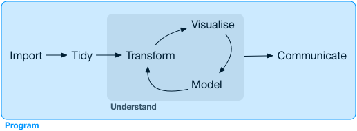

# Pipes

```r
library(magrittr) # you don't need the entire tidyverse for pipes
```

Why is the pipe so useful?

## Piping alternatives

> Little bunny Foo Foo  
> Went hopping through the forest  
> Scooping up the field mice  
> And bopping them on the head  
> - Chilren’s poem

Define an object to represent little bunny Foo Foo:

```r
foo_foo <- little_bunny()
```

Use a function for each key verb: `hop()`, `scoop()`, and `bop()`.

Using this object and these verbs, there are (at least) four ways we could retell the story in code:

1. Save each intermediate step as a new object.
2. Overwrite the original object many times.
3. Compose functions.
4. Use the pipe.

### Save each intermediate steps

```r
foo_foo_1 <- hop(foo_foo, through = forest)
foo_foo_2 <- scoop(foo_foo_1, up = field_mice)
foo_foo_3 <- bop(foo_foo_2, on = head)
```

- Simple.
- Downside – you must name each intermediate element.
- Many copies of your data may takes up a lot of memory (R manages this concern pretty well, though).

### Overwrite the original

Instead of creating intermediate objects at each step, we could overwrite the original object:

```r
foo_foo <- hop(foo_foo, through = forest)
foo_foo <- scoop(foo_foo, up = field_mice)
foo_foo <- bop(foo_foo, on = head)
```

Less typing (and less thinking about object names), but:

1. Debugging is painful: if you make a mistake you’ll need to re-run the complete pipeline from the beginning.
2. The repetition of the object being transformed (we’ve written `foo_foo` six times!) obscures what’s changing on each line.

### Function composition

Abandon assignment and just string the function calls together:

```r
bop(
  scoop(
    hop(foo_foo, through = forest),
    up = field_mice
  ),
  on = head
)
```

Disadvantages:

1. You have to read from inside-out, from right-to-left.
2. Arguments end up spread far apart.

### Use the pipe

```r
foo_foo %>%
  hop(through = forest) %>%
  scoop(up = field_mice) %>%
  bop(on = head)
```

Advantages:

1. It focusses on verbs, not nouns.
2. Sequential: Foo Foo hops, then scoops, then bops.

Downside:

- you need to be familiar with the pipe.

Behind the scenes:

magrittr reassembles the code in the pipe to a form that works by overwriting an intermediate object:

```r
my_pipe <- function(.) {
  . <- hop(., through = forest)
  . <- scoop(., up = field_mice)
  bop(., on = head)
}
my_pipe(foo_foo)
```

## When the pipes doesn’t work

1. Functions that use the current environment: `assign()`, `get()`, `load()`.

   ```r
   # create a new variable with the given name in the current environment:
   assign("x", 10)
   x
   ```

   ```
   ## [1] 10
   ```

   ```r
   "x" %>% assign(100)
   x
   ```

   ```
   ## [1] 10
   ```

   The pipe assigns it to a temporary environment used by `%>%`. If you do want to use assign with the pipe, you must be explicit about the environment:

   ```r
   env <- environment()
   "x" %>% assign(100, envir = env)
   x
   ```

   ```
   ## [1] 100
   ```

2. Functions that use lazy evaluation: `tryCatch()`, `try()`, `suppressMessages()`, `suppressWarnings()`.

   ```r
   tryCatch(stop("!"), error = function(e) "An error")
   ```

   ```
   ## [1] "An error"
   ```

   ```r
   stop("!") %>%
     tryCatch(error = function(e) "An error")
   ```

   ```
   ## Error in eval(lhs, parent, parent): !
   ```

   In R, function arguments are only computed when the function uses them, not prior to calling the function. The pipe computes each element in turn, so you can’t rely on this behaviour.

## When not to use the pipe

- Your pipes are longer than (say) ten steps. In that case, create intermediate objects with meaningful names.
- You have multiple inputs or outputs. If there isn’t one primary object being transformed, but two or more objects being combined together, don’t use the pipe.
- You are starting to think about a directed graph with a complex dependency structure. Pipes are fundamentally linear and expressing complex relationships with them will typically yield confusing code.

## Other tools from magrittr

- T pipe: when call a function for its side-effects, which may not return anything.

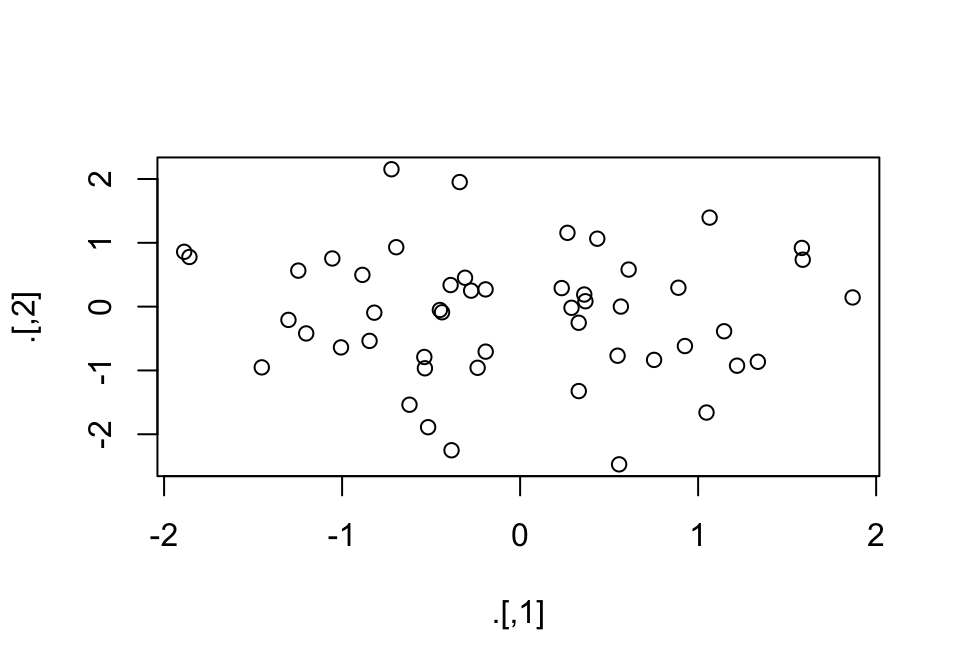

  ```r
  rnorm(100) %>%
    matrix(ncol = 2) %>%
    plot() %>%
    str()
  ```

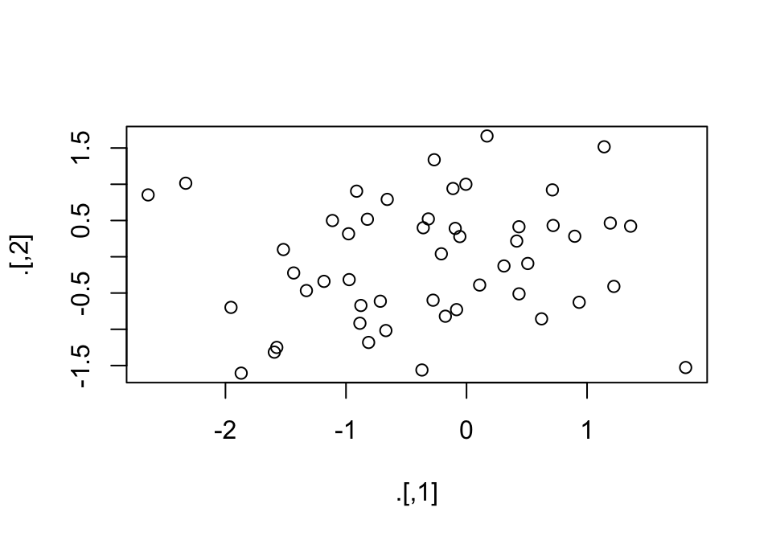

  ```
  ##  num [1:50, 1:2] -0.176 -0.885 -1.954 -1.594 -0.37 ...
  ```

  ```r
  rnorm(100) %>%
    matrix(ncol = 2) %T>%
    plot() %>%
    str()
  ```

  `%T%` returns the left-hand side instead of the right-hand.
- `%$%`: when working with functions that don’t have a data frame based API.

  ```r
  mtcars %$%
    cor(disp, mpg)   # `cor()` requires vector inputs
  ```

  ```
  ## [1] -0.8475514
  ```

- `%<>%` for assignment: instead of

  ```r
  mtcars <- mtcars %>%
    transform(cyl = cyl * 2)
  ```

  you may like

  ```r
  mtcars %<>% transform(cyl = cyl * 2)
  ```